# Terrain Statistics for Reference Earthflows

Lorena Abad

19.10.2020

# Context

As a continuation of the [terrain derivative generation](https://loreabad6.github.io/Earthflows_R/terrain_derivatives.html) of the Tiraumea catchment in New Zealand to identify earthflows, we calculate several statistics computed for manually delineated earthflows, taken as a reference for analysis.

# Manual delineation of earthflows

Based on RGBI mosaics for the Tiraumea catchment for 2016, 39 earthflows were manually delineated for our area of interest. They are fairly distributed within the study area.

```r
#' Load reference data ----
#' Reference data for manually delineated earthflows
ef = st_read('data_reference/earthflow_statistics.shp', quiet = T) %>%
  select(Area_m2, Compactnes, Density, DSMmaxmin, elev_by_le, Length_m, LengthWidt) %>%
  rowid_to_column(var = 'ID')
ef
```

| ID | Area_m2 | Compactnes | Density | DSMmaxmin | elev_by_le | Length_m | LengthWidt | geometry |
| --- | --- | --- | --- | --- | --- | --- | --- | --- |
| 1 | 1908 | 1.626225 | 1.270803 | 57.42000 | 0.4769003 | 120.40253 | 4.672101 |  |
| 2 | 13899 | 1.312832 | 1.594164 | 123.70000 | 0.4743304 | 260.78870 | 3.727218 |  |
| 3 | 8686 | 1.665612 | 1.758396 | 45.45001 | 0.2212291 | 205.44323 | 2.917359 |  |
| 4 | 5473 | 1.860529 | 2.020188 | 39.91000 | 0.3313561 | 120.44444 | 1.424661 |  |
| 5 | 22485 | 1.526343 | 1.550135 | 71.41000 | 0.2164854 | 329.86061 | 3.170413 |  |
| 6 | 147295 | 1.471975 | 2.362691 | 115.47000 | 0.2061749 | 560.05861 | 1.446700 |  |
| 7 | 5040 | 1.287364 | 2.314093 | 47.01999 | 0.4853359 | 96.88133 | 1.446600 |  |
| 8 | 1010 | 1.330693 | 1.871105 | 28.95001 | 0.5169645 | 56.00000 | 2.333333 |  |
| 9 | 925 | 1.292973 | 1.848628 | 30.45001 | 0.5855772 | 52.00000 | 2.260870 |  |
| 10 | 3252 | 1.406697 | 1.726349 | 55.16000 | 0.4888830 | 112.82863 | 2.782834 |  |

[output cut: 29 more lines]

```r
tiraumea = st_read('study_area/Tiraumea.shp', quiet = T)
mapview(tiraumea, color = 'red', alpha.regions = 0) + mapview(ef, zcol = 'Area_m2')
```

[interactive chart not shown]

Several variables were already calculated within eCognition, and are shown on the data frame above. Here is a small description of this variables:

- Area_m2: Area in square meters of the object
- Compactness: Product of the width and the length over pixels numbers
- Density: Distribution, in space, of the pixels of an object and is calculated by the Area object
- DSMmaxmin: Range between min and max
- elev_by_le: Elevation by length, i.e. DSM_minmax / length
- Length_m: length in meters of the object
- LengthWidt: ratio length / width

As a final step, the delineated earthflows are filtered to the study area of interested, and reprojected.

```r
#' Filter those earthflows on the area of interest
ef_aoi = ef %>%
  st_transform(crs = st_crs(derivatives)) %>%
  st_filter(ef, st_as_sfc(st_bbox(derivatives)))
```

# Terrain derivatives as proxies

The terrain derivatives were calculated for 32 variables for the original DSM data (1 m spatial resolution), and also for a filtered DSM on a 3x3 moving window. One variable was calculated on a resampled 3m resolution DSM. Each layer is around 5 GB large, so they are called into the R environment as proxies.

```r
#' Load rasters as proxy objects ----
#' Set the path to terrain derivatives
# file_path = "G:\\STEC\\04_Data\\Earthflows\\selected_study_areas\\complete_tiraumea_catchment\\derivatives"
file_path = "//shares/sfs_0165_1/ZGIS/RESEARCH/02_PROJECTS/01_P_330001/119_STEC/04_Data/Earthflows/selected_study_areas/study_area_1/out_terrain_products/"
#' List the files of interest: GeoTIFF files
files = list.files(path = file_path, pattern = ".tif$", full.names = T)
#' Filter the files to those computed with the original DEM and the 3x3 filtered DEM
filtered = files[grep("^(?!.*7x7|.*5x5|.*3m)", files, perl = T)]
#' Filter files for the DEM computed at 3m resample
filtered_3m = files[grep("^(.*3m)", files, perl = T)]
#' Load the files in a single stars proxy object
#' with one attribute per terrain derivative (leave `along` as `NA_integer_` for that)
derivatives = read_stars(filtered, proxy = T)
#' 3m data is loaded separate since resolution differs
derivatives_3m = read_stars(filtered_3m, proxy = T)
```

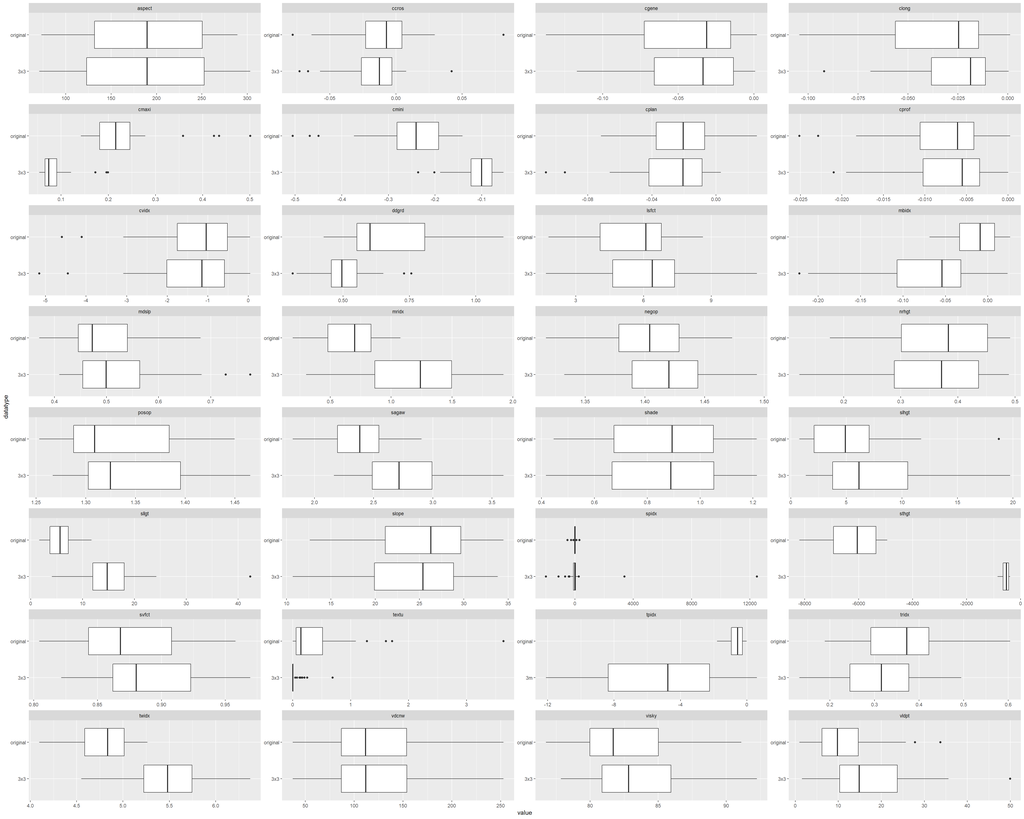

```r
load("statistics/earthflow_stats_long.Rda")
p = stats_long %>%
  filter(statistic == 'mean') %>%
  # Histogram of the values
  ggplot(aes(x = value, y = datatype)) +
  geom_boxplot() +
  # geom_histogram(bins = 10) +
  facet_wrap(~derivative, scales = 'free', ncol = 4)
  # Scatterplot of two values
  # Map of the values
  # ggplot() +
  # geom_sf(aes(fill = value), color = NA) +
  # scale_fill_viridis_c() +
  # theme_void()

p #%>%
```

```r
  #plotly::ggplotly()
```